# Style transfer

Здесь представлена реализация Style transfer'a. Основная идея алгоритма состоит в том, чтобы некоторым образом научится выделять стиль изображение и его контент. Получив такое разделение, попытаемся выделить стиль одного изображения (style image), а контент (content image) другого и получить третье изображение (target image), объединяющее выделенные характеристики первых двух.

Сначала импортируем необходимые библиотеки.

```python
import torch
import torch.nn as nn
import torch.nn.functional as F

from torchvision import transforms, models
from PIL import Image

import copy
from tqdm.notebook import tqdm
from collections import defaultdict
import matplotlib.pyplot as plt
%matplotlib inline
```

Установим устройство, на котором будем работать.

```python
device = 'cuda:0' if torch.cuda.is_available else 'cpu'
```

Скачаем изображения, с которыми будем работать. Из одного будем брать контент, а с другого контент.

```python
!wget https://encrypted-tbn0.gstatic.com/images?q=tbn:ANd9GcRo3HtMgwTtfczsh84loJ97I2uy9MsWKRRCAVuEXht_3PmybVPY_WH1QG5eMwb4bci6KuVPhIssBgws-gHB6k_oATkEkxFYPtg&usqp=CAU&ec=45732303
!wget https://pytorch.org/tutorials/_static/img/neural-style/dancing.jpg
```

Мы будем использовать уже обученную модель vgg19, которая работает с нормализованными изображениями. Поэтому напишем вспомогательные функции для нормировки и денормировки изображений.

```python
def normalize(img):
    mean = torch.tensor([0.485, 0.456, 0.406]).view(-1, 1, 1).to(device)
    std = torch.tensor([0.229, 0.224, 0.225]).view(-1, 1, 1).to(device)
    return (img - mean) / std

def denormalize(img):
    mean = torch.tensor([0.485, 0.456, 0.406]).view(-1, 1, 1).to(device)
    std = torch.tensor([0.229, 0.224, 0.225]).view(-1, 1, 1).to(device)
    return img * std + mean
```

Опишем функции загрузки и отрисовки изображений.

```python
def load_image(path):
    imsize = (512, 512) if torch.cuda.is_available else (128, 128)

    transformer = transforms.Compose([
        transforms.Resize(imsize),
        transforms.ToTensor()
    ])

    img = Image.open(path)
    img = transformer(img).unsqueeze(0).to(device, torch.float)
    return img

def imshow(image, title=None):
    image = image.cpu().clone().squeeze(0)
    image = transforms.ToPILImage()(image)

    f, ax = plt.subplots()
    ax.imshow(image)
    ax.axis('off')

    if title != None:
        ax.set_title(title)

    plt.show()
```

Загрузим их и выведем на экран.

[figure not shown]

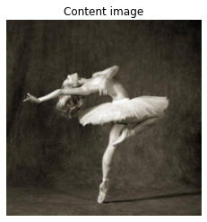

```python
style_img = load_image('/content/images?q=tbn:ANd9GcRo3HtMgwTtfczsh84loJ97I2uy9MsWKRRCAVuEXht_3PmybVPY_WH1QG5eMwb4bci6KuVPhIssBgws-gHB6k_oATkEkxFYPtg')
content_img = load_image('/content/dancing.jpg')
imshow(style_img, title='Style image')
imshow(content_img, title='Content image')
```

Загрузим предобученную vgg19.

```python
vgg = models.vgg19(pretrained=True).features.to(device).eval()
vgg
```

```
Sequential(
  (0): Conv2d(3, 64, kernel_size=(3, 3), stride=(1, 1), padding=(1, 1))
  (1): ReLU(inplace=True)
  (2): Conv2d(64, 64, kernel_size=(3, 3), stride=(1, 1), padding=(1, 1))
  (3): ReLU(inplace=True)
  (4): MaxPool2d(kernel_size=2, stride=2, padding=0, dilation=1, ceil_mode=False)
  (5): Conv2d(64, 128, kernel_size=(3, 3), stride=(1, 1), padding=(1, 1))
  (6): ReLU(inplace=True)
  (7): Conv2d(128, 128, kernel_size=(3, 3), stride=(1, 1), padding=(1, 1))
  (8): ReLU(inplace=True)
  (9): MaxPool2d(kernel_size=2, stride=2, padding=0, dilation=1, ceil_mode=False)
  (10): Conv2d(128, 256, kernel_size=(3, 3), stride=(1, 1), padding=(1, 1))
  (11): ReLU(inplace=True)
  (12): Conv2d(256, 256, kernel_size=(3, 3), stride=(1, 1), padding=(1, 1))
  (13): ReLU(inplace=True)
  (14): Conv2d(256, 256, kernel_size=(3, 3), stride=(1, 1), padding=(1, 1))
  (15): ReLU(inplace=True)
  (16): Conv2d(256, 256, kernel_size=(3, 3), stride=(1, 1), padding=(1, 1))
  (17): ReLU(inplace=True)
  (18): MaxPool2d(kernel_size=2, stride=2, padding=0, dilation=1, ceil_mode=False)
  (19): Conv2d(256, 512, kernel_size=(3, 3), stride=(1, 1), padding=(1, 1))
  (20): ReLU(inplace=True)
  (21): Conv2d(512, 512, kernel_size=(3, 3), stride=(1, 1), padding=(1, 1))
  (22): ReLU(inplace=True)
  (23): Conv2d(512, 512, kernel_size=(3, 3), stride=(1, 1), padding=(1, 1))
  (24): ReLU(inplace=True)
  (25): Conv2d(512, 512, kernel_size=(3, 3), stride=(1, 1), padding=(1, 1))
  (26): ReLU(inplace=True)
  (27): MaxPool2d(kernel_size=2, stride=2, padding=0, dilation=1, ceil_mode=False)
  (28): Conv2d(512, 512, kernel_size=(3, 3), stride=(1, 1), padding=(1, 1))
  (29): ReLU(inplace=True)
  (30): Conv2d(512, 512, kernel_size=(3, 3), stride=(1, 1), padding=(1, 1))
  (31): ReLU(inplace=True)
  (32): Conv2d(512, 512, kernel_size=(3, 3), stride=(1, 1), padding=(1, 1))
  (33): ReLU(inplace=True)
  (34): Conv2d(512, 512, kernel_size=(3, 3), stride=(1, 1), padding=(1, 1))
  (35): ReLU(inplace=True)
  (36): MaxPool2d(kernel_size=2, stride=2, padding=0, dilation=1, ceil_mode=False)
)
```

Как уже говорилось, vgg19 обучалась на нормированных изображениях, поэтому опишем слой Normalization, который будет первым в нашей сети.

```python
class Normalization(nn.Module):
    def __init__(self, mean, std):
        super().__init__()
        self.mean = mean.view(-1, 1, 1)
        self.std = std.view(-1, 1, 1)

    def forward(self, x):
        return (x - self.mean) / self.std
```

Теперь введем несколько понятий, первое из них -- Content loss. Прогоним через vgg 2 изображения. Тогда их мерой схожести будем считать $L_2$-норму между выходами некоторого сверточного слоя $l$ сети. $$ L_c^l = ||F^l_1 - F^l_2||_2 $$ где $F^l_1$ -- выход $l$-ого слоя при прогоне первого изображения, а $F^l_2$ -- второго.

Тогда Content loss'ом назовем $L_c^l$ между content image и target image.

Для реализации этого опишем слой, который имеет 2 поля:

1. target -- $F^l$ для content image.
2. loss -- Content loss

```python
class ContentLoss(nn.Module):
    def __init__(self, target):
        super().__init__()
        self.target = target.detach()
        self.loss = 0

    def forward(self, current):
        self.loss = F.mse_loss(self.target, current)
        return current
```

Style loss'ом будем называть некоторым образом измеренную разницу между стилями style image и target image.

Определим $S^l$ -- style loss на слое $l$. Тогда пусть он будет равен: $$ S^l = ||G_s - G_t||_2 $$ где $G_s$ и $G_t$ -- матрицы Грама для style image и target image.

Тогда Style Loss: $$ L_s = \sum_l S^l $$

Для реализации определим вспомогательную функцию для подсчета матрицы Грама и слой с полями:

1. gram_target -- матрица Грама для style image.
2. loss -- $S^l$

```python
def gram_matrix(tensor):
    a, b, c, d = tensor.size()
    result = tensor.view(a * b, c * d)
    G = torch.mm(result, result.t())
    G = G.div(a * b * c * d)
    return G
```

```python
class StyleLoss(nn.Module):
    def __init__(self, target):
        super().__init__()
        self.gram_target = gram_matrix(target.detach())
        self.loss = 0

    def forward(self, current):
        gram_current = gram_matrix(current)
        self.loss = F.mse_loss(self.gram_target, gram_current)
        return current
```

Определим слои, которые будем использовать дял подсчета лоссов, а так же константы для нормирования изображений.

```python
content_layers_default = ['conv_4']
style_layers_default = ['conv_1', 'conv_2', 'conv_3', 'conv_4', 'conv_5']
cnn_normalization_mean = torch.tensor([0.485, 0.456, 0.406]).to(device)
cnn_normalization_std = torch.tensor([0.229, 0.224, 0.225]).to(device)
```

Опишем функцию, которая будем возвращать модель -- в нее добавим только те слои из vgg19, которые будем использовать, а так же слои:

1. Normalization -- сделаем его самым первым.
2. ContentLoss -- после блоков, у выходов которых мы хотим считать сходство контентов изображений.
3. StyleLoss -- после слоев, для которых будем считать сходсво стилей.

Так же функция возвращает список экземпляров классов StyleLoss и ContentLoss. У них в поле loss будут лежать лоссы на текущем слое.

```python
def get_model_and_losses(vgg, style, content,
                         content_layers = content_layers_default,
                         style_layers = style_layers_default,
                         norm_mean = cnn_normalization_mean,
                         norm_std = cnn_normalization_std):

    model = nn.Sequential(Normalization(norm_mean, norm_std)).to(device)
    style_losses = []
    content_losses = []

    counter = defaultdict(int)

    for layer in vgg.children():
        if isinstance(layer, nn.Conv2d):
            counter['conv'] += 1
            name = 'conv_' + str(counter['conv'])
        elif isinstance(layer, nn.ReLU):
            counter['relu'] += 1
            name = 'relu_' + str(counter['relu'])
            layer = nn.ReLU(inplace=False)
        elif isinstance(layer, nn.MaxPool2d):
            counter['pool'] += 1
            name = 'pool_' + str(counter['pool'])
        else:
            print('Met unrecognised layer')

        model.add_module(name, layer)

        if name in content_layers:
            target = model(content)
            content_loss_layer = ContentLoss(target)
            model.add_module('content_loss_' + str(counter['conv']), content_loss_layer)
            content_losses.append(content_loss_layer)

        if name in style_layers:
            target = model(style)
            style_loss_layer = StyleLoss(target)
            model.add_module('style_loss_' + str(counter['conv']), style_loss_layer)
            style_losses.append(style_loss_layer)

    for i in range(len(model) - 1, -1, -1):
        if isinstance(model[i], ContentLoss) or isinstance(model[i], StyleLoss):
            model = model[:i + 1]
            break

    return model, content_losses, style_losses
```

Изображение, на котором мы хотим получит смешение стилей обычно делают равным изображению с контентом, хотя можно сделать его просто шумом.

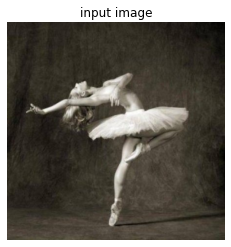

```python
input_img = content_img.clone()
imshow(input_img, title='input image')
```

Опишем функцию запуска Style transfer'a. Она принимает vgg, target image, content image, style image, а так же необязательные параметры num_iter -- число итераций и alpha -- коэффициент, с которым в итоговый лосс входят Style loss и Content loss.

Функция так же будет выводить промежуточные значения лоссов и результата.

```python
def run_style_transfer(vgg, input, content, style, num_iter=1000, alpha=10000000):

    model, content_losses, style_losses = get_model_and_losses(vgg, style, content)

    optimizer = torch.optim.LBFGS([input.requires_grad_()])

    run_num = [0]
    content_history = []
    style_history = []
    loss_history = []
    while (run_num[0] < num_iter):

        def closure():
            input.data.clamp_(0, 1)
            optimizer.zero_grad()

            style_loss = 0
            content_loss = 0
            model(input)

            for l in content_losses:
                content_loss += l.loss
            for l in style_losses:
                style_loss += l.loss

            loss = style_loss * alpha + content_loss
            loss.backward()

            content_history.append(content_loss)
            style_history.append(style_loss)
            loss_history.append(loss.item())

            run_num[0] += 1
            if run_num[0] % 100 == 0:
                print('Iteration: {}'.format(run_num[0]))
                print('Content loss: {:4f}, Style loss: {:4f}'.format(content_loss, style_loss * alpha))

            if run_num[0] % 200 == 0:
                imshow(input)
                f, ax = plt.subplots(1, 3, figsize=(20, 5))
                ax[0].plot(content_history)
                ax[0].set_title('content loss')

                ax[1].plot(style_history)
                ax[1].set_title('style loss')

                ax[2].plot(loss_history)
                ax[2].set_title('summary loss')
                plt.show()

            return style_loss * alpha + content_loss

        optimizer.step(closure)

    input.data.clamp_(0, 1)
    return input
```

Запустим Style transfer и вывдем результат.

```
Iteration: 100
Content loss: 11.929287, Style loss: 494.961609
Iteration: 200
Content loss: 13.592688, Style loss: 155.574890
```

[figure not shown]

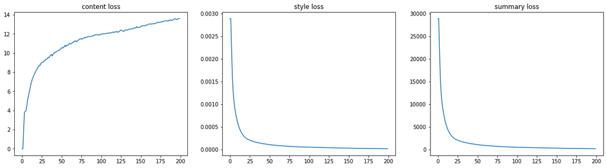

```
Iteration: 300
Content loss: 14.211418, Style loss: 48.623425
Iteration: 400
Content loss: 13.901220, Style loss: 21.192352
```

[figure not shown]

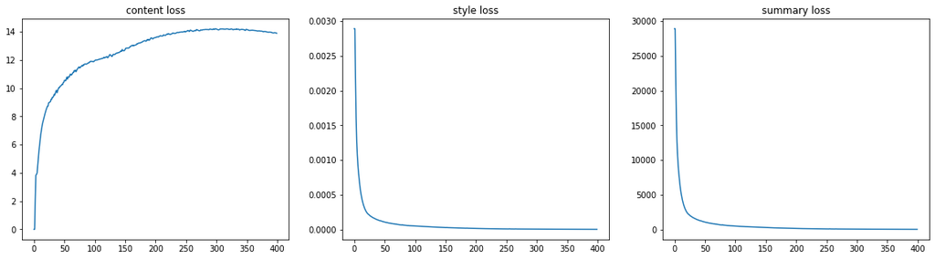

```
Iteration: 500
Content loss: 13.116904, Style loss: 10.984751
Iteration: 600
Content loss: 12.146396, Style loss: 6.071505
```

[figure not shown]

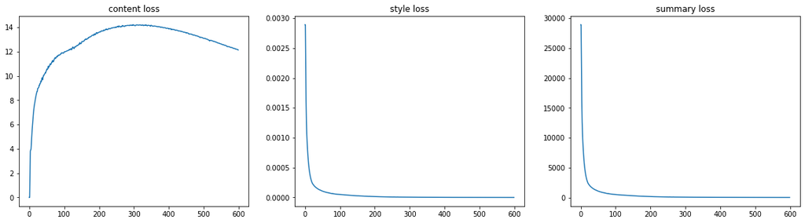

```
Iteration: 700
Content loss: 11.282080, Style loss: 3.687645
Iteration: 800
Content loss: 10.578991, Style loss: 2.402707
```

[figure not shown]

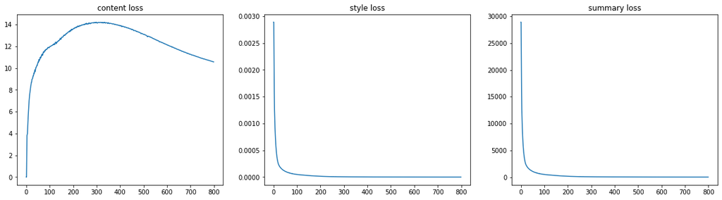

```
Iteration: 900
Content loss: 9.990928, Style loss: 1.661964
Iteration: 1000
Content loss: 9.535952, Style loss: 1.251212
```

[figure not shown]

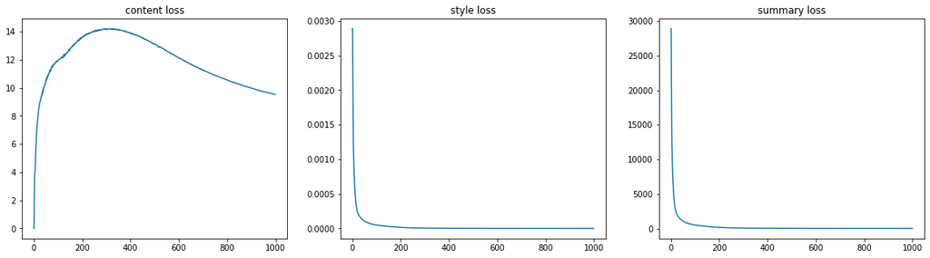

[figure not shown]

```python
result = run_style_transfer(vgg, input_img, content_img, style_img)

imshow(result)
```